# Topic 4 Exercises: Classification

# Programming Assignment: 4.7.11

# 4.7.11 car mileage with Auto dataset

a.create data frame with mpg01

```r
new_Auto<-data.frame(Auto)
Auto$mpg01<-ifelse(Auto$mpg>median(Auto$mpg),1,0)
```

2. which best to predict mpg? Use scatterplots and boxplots

```r
all<-lm(mpg~. -name,data=Auto)
summary(all)
```

```
##
## Call:
## lm(formula = mpg ~ . - name, data = Auto)
##
## Residuals:
##     Min      1Q  Median      3Q     Max
## -6.8658 -1.7465 -0.0228  1.3575 13.0212
##
## Coefficients:
##                Estimate Std. Error t value Pr(>|t|)
## (Intercept)  -1.358e+01  4.002e+00  -3.394  0.00076 ***
## cylinders     1.820e-01  2.836e-01   0.642  0.52140
## displacement  1.796e-02  6.458e-03   2.780  0.00570 **
## horsepower   -2.912e-02  1.189e-02  -2.449  0.01478 *
## weight       -4.833e-03  5.774e-04  -8.371 1.09e-15 ***
## acceleration  6.741e-02  8.492e-02   0.794  0.42780
## year          5.823e-01  4.609e-02  12.635  < 2e-16 ***
## origin        1.159e+00  2.400e-01   4.827 2.00e-06 ***
## mpg01         5.711e+00  4.874e-01  11.718  < 2e-16 ***
## ---
## Signif. codes:  0 '***' 0.001 '**' 0.01 '*' 0.05 '.' 0.1 ' ' 1
##
## Residual standard error: 2.859 on 383 degrees of freedom
## Multiple R-squared:  0.8686, Adjusted R-squared:  0.8658
## F-statistic: 316.4 on 8 and 383 DF,  p-value: < 2.2e-16
```

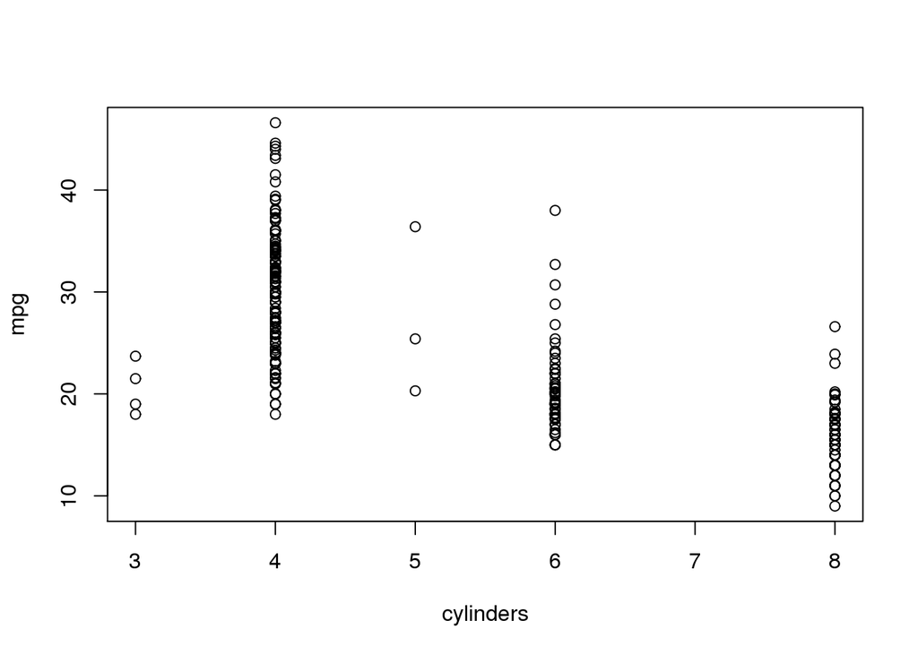

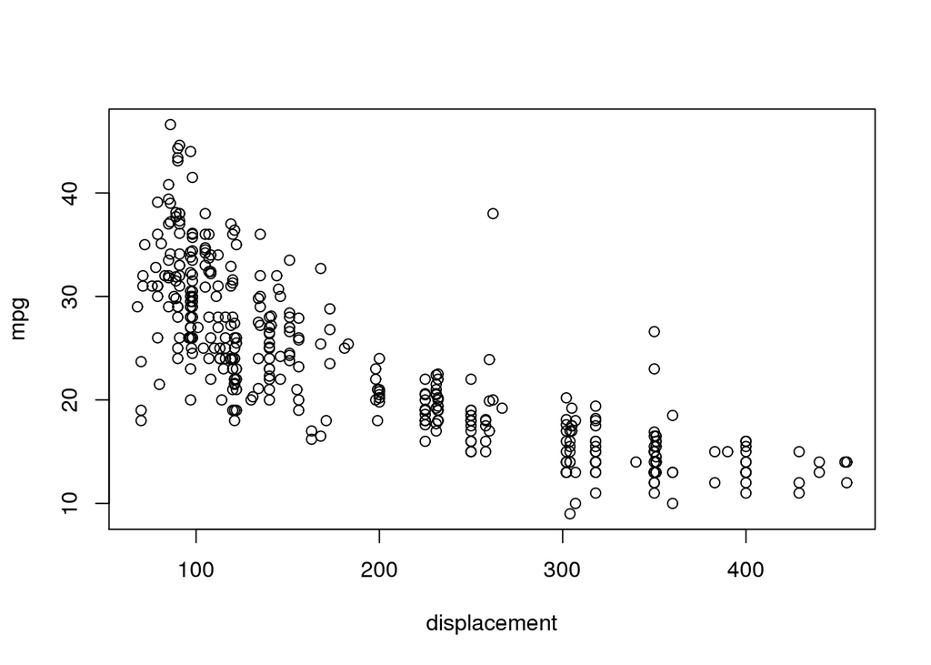

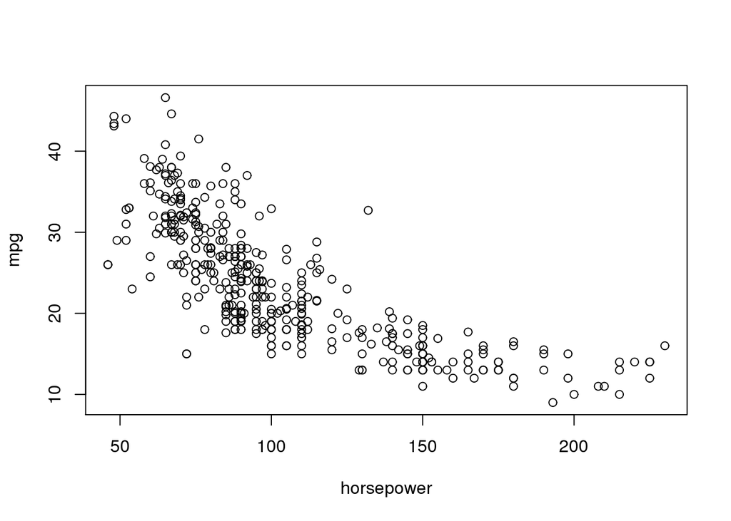

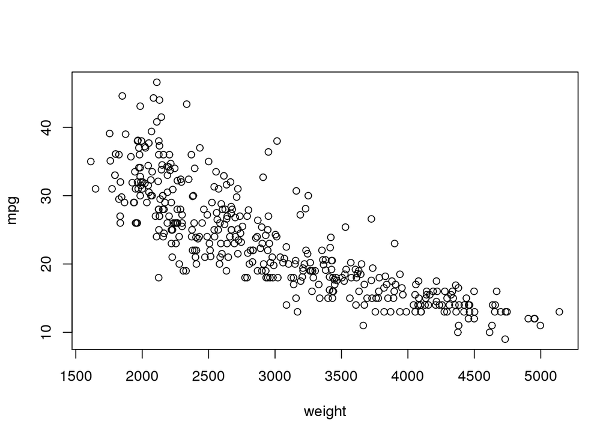

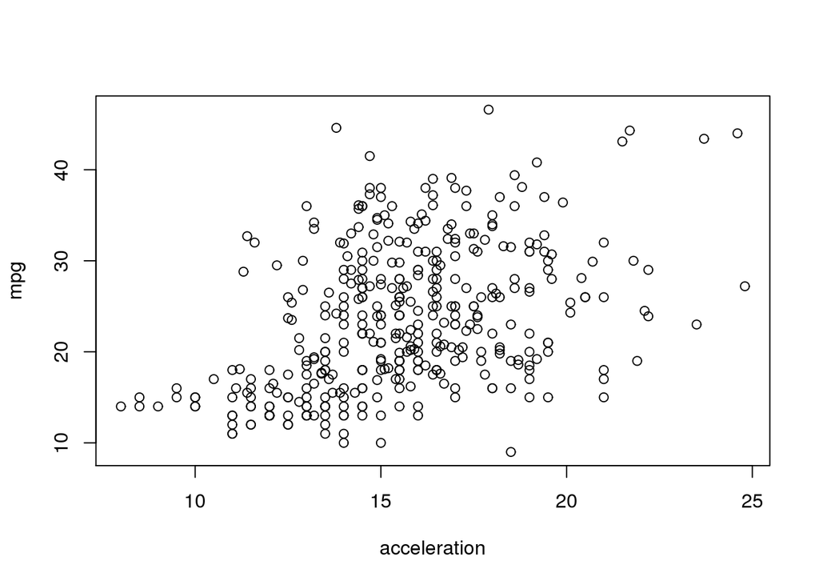

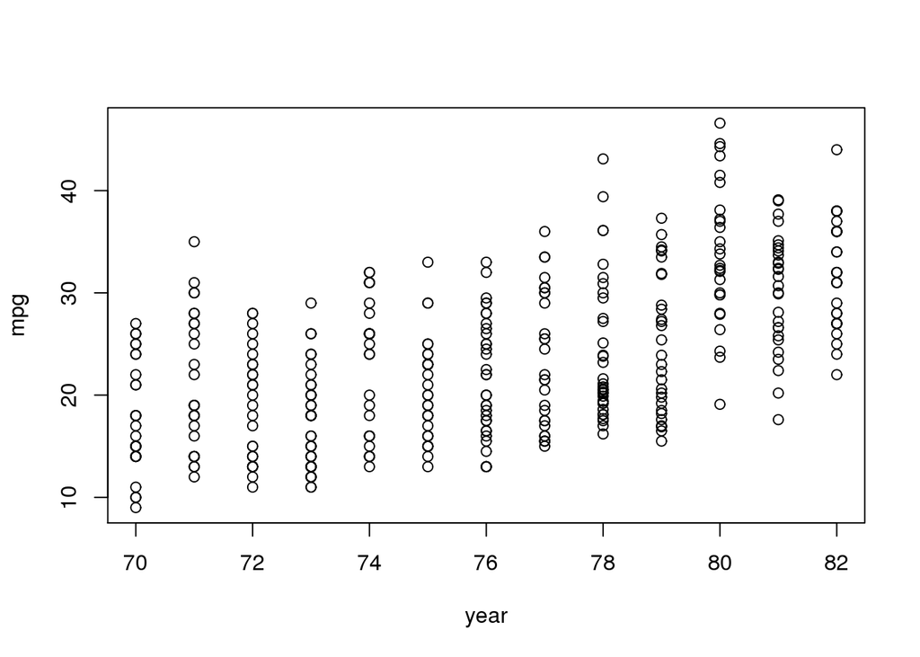

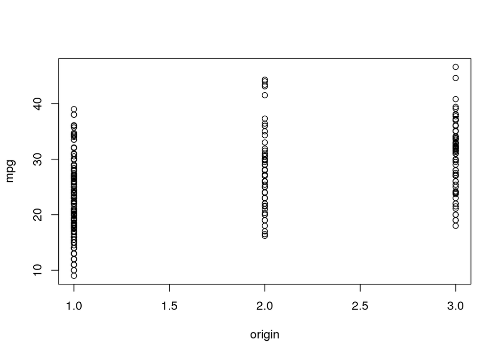

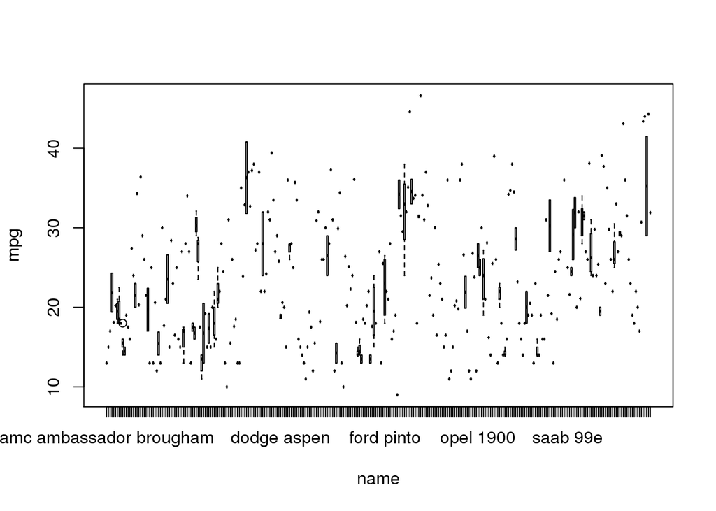

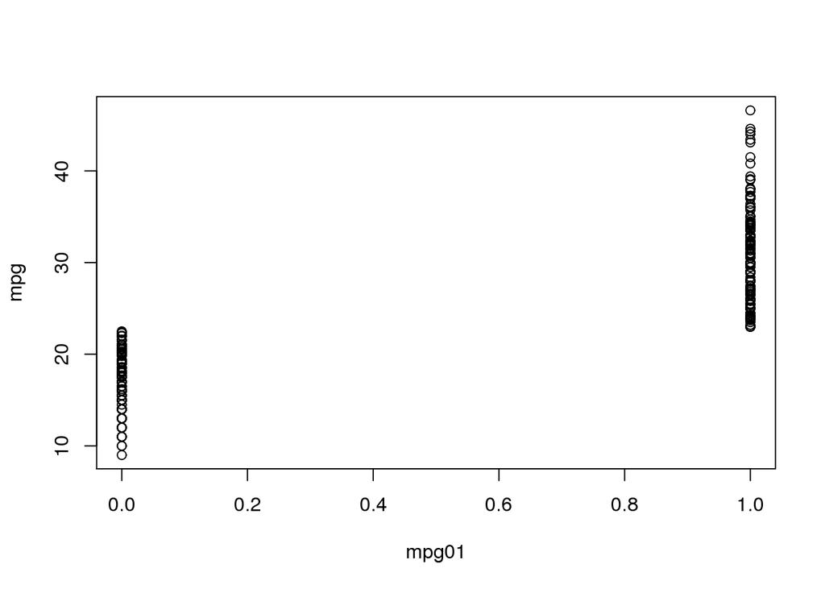

```r
plot(mpg~.,data=Auto)
```

b.Based on the above plots, it appears that cylindres, displacement, horsepower, and weight all predict mpg fairly well.

```r
cylinder<-lm(mpg~cylinders,data=Auto)
summary(cylinder) #R2 = .6047
```

```
##
## Call:
## lm(formula = mpg ~ cylinders, data = Auto)
##
## Residuals:
##      Min       1Q   Median       3Q      Max
## -14.2413  -3.1832  -0.6332   2.5491  17.9168
##
## Coefficients:
##             Estimate Std. Error t value Pr(>|t|)
## (Intercept)  42.9155     0.8349   51.40   <2e-16 ***
## cylinders    -3.5581     0.1457  -24.43   <2e-16 ***
## ---
## Signif. codes:  0 '***' 0.001 '**' 0.01 '*' 0.05 '.' 0.1 ' ' 1
##
## Residual standard error: 4.914 on 390 degrees of freedom
## Multiple R-squared:  0.6047, Adjusted R-squared:  0.6037
## F-statistic: 596.6 on 1 and 390 DF,  p-value: < 2.2e-16
```

```r
displacement<-lm(mpg~displacement,data=Auto)
summary(displacement) #R2 = .6482
```

```
##
## Call:
## lm(formula = mpg ~ displacement, data = Auto)
##
## Residuals:
##      Min       1Q   Median       3Q      Max
## -12.9170  -3.0243  -0.5021   2.3512  18.6128
##
## Coefficients:
##              Estimate Std. Error t value Pr(>|t|)
## (Intercept)  35.12064    0.49443   71.03   <2e-16 ***
## displacement -0.06005    0.00224  -26.81   <2e-16 ***
## ---
## Signif. codes:  0 '***' 0.001 '**' 0.01 '*' 0.05 '.' 0.1 ' ' 1
##
## Residual standard error: 4.635 on 390 degrees of freedom
## Multiple R-squared:  0.6482, Adjusted R-squared:  0.6473
## F-statistic: 718.7 on 1 and 390 DF,  p-value: < 2.2e-16
```

```r
horsepower<-lm(mpg~horsepower,data=Auto)
summary(horsepower) #R2 = .6059
```

```
##
## Call:
## lm(formula = mpg ~ horsepower, data = Auto)
##
## Residuals:
##      Min       1Q   Median       3Q      Max
## -13.5710  -3.2592  -0.3435   2.7630  16.9240
##
## Coefficients:
##              Estimate Std. Error t value Pr(>|t|)
## (Intercept) 39.935861   0.717499   55.66   <2e-16 ***
## horsepower  -0.157845   0.006446  -24.49   <2e-16 ***
## ---
## Signif. codes:  0 '***' 0.001 '**' 0.01 '*' 0.05 '.' 0.1 ' ' 1
##
## Residual standard error: 4.906 on 390 degrees of freedom
## Multiple R-squared:  0.6059, Adjusted R-squared:  0.6049
## F-statistic: 599.7 on 1 and 390 DF,  p-value: < 2.2e-16
```

```r
weight<-lm(mpg~weight,data=Auto)
summary(weight) #R2 = .69
```

```
##
## Call:
## lm(formula = mpg ~ weight, data = Auto)
##
## Residuals:
##      Min       1Q   Median       3Q      Max
## -11.9736  -2.7556  -0.3358   2.1379  16.5194
##
## Coefficients:
##              Estimate Std. Error t value Pr(>|t|)
## (Intercept) 46.216524   0.798673   57.87   <2e-16 ***
## weight      -0.007647   0.000258  -29.64   <2e-16 ***
## ---
## Signif. codes:  0 '***' 0.001 '**' 0.01 '*' 0.05 '.' 0.1 ' ' 1
##
## Residual standard error: 4.333 on 390 degrees of freedom
## Multiple R-squared:  0.6926, Adjusted R-squared:  0.6918
## F-statistic: 878.8 on 1 and 390 DF,  p-value: < 2.2e-16
```

```r
acceleration<-lm(mpg~acceleration,data=Auto)
summary(acceleration) #R2 = .1792
```

```
##
## Call:
## lm(formula = mpg ~ acceleration, data = Auto)
##
## Residuals:
##     Min      1Q  Median      3Q     Max
## -17.989  -5.616  -1.199   4.801  23.239
##
## Coefficients:
##              Estimate Std. Error t value Pr(>|t|)
## (Intercept)    4.8332     2.0485   2.359   0.0188 *
## acceleration   1.1976     0.1298   9.228   <2e-16 ***
## ---
## Signif. codes:  0 '***' 0.001 '**' 0.01 '*' 0.05 '.' 0.1 ' ' 1
##
## Residual standard error: 7.08 on 390 degrees of freedom
## Multiple R-squared:  0.1792, Adjusted R-squared:  0.1771
## F-statistic: 85.15 on 1 and 390 DF,  p-value: < 2.2e-16
```

```r
year<-lm(mpg~year,data=Auto)
summary(year) #R2 = .337
```

```
##
## Call:
## lm(formula = mpg ~ year, data = Auto)
##
## Residuals:
##      Min       1Q   Median       3Q      Max
## -12.0212  -5.4411  -0.4412   4.9739  18.2088
##
## Coefficients:
##              Estimate Std. Error t value Pr(>|t|)
## (Intercept) -70.01167    6.64516  -10.54   <2e-16 ***
## year          1.23004    0.08736   14.08   <2e-16 ***
## ---
## Signif. codes:  0 '***' 0.001 '**' 0.01 '*' 0.05 '.' 0.1 ' ' 1
##
## Residual standard error: 6.363 on 390 degrees of freedom
## Multiple R-squared:  0.337,  Adjusted R-squared:  0.3353
## F-statistic: 198.3 on 1 and 390 DF,  p-value: < 2.2e-16
```

```r
origin<-lm(mpg~origin,data=Auto)
summary(origin) #R2 = .3195
```

```
##
## Call:
## lm(formula = mpg ~ origin, data = Auto)
##
## Residuals:
##      Min       1Q   Median       3Q      Max
## -13.2416  -5.2533  -0.7651   3.8967  18.7115
##
## Coefficients:
##             Estimate Std. Error t value Pr(>|t|)
## (Intercept)  14.8120     0.7164   20.68   <2e-16 ***
## origin        5.4765     0.4048   13.53   <2e-16 ***
## ---
## Signif. codes:  0 '***' 0.001 '**' 0.01 '*' 0.05 '.' 0.1 ' ' 1
##
## Residual standard error: 6.447 on 390 degrees of freedom
## Multiple R-squared:  0.3195, Adjusted R-squared:  0.3177
## F-statistic: 183.1 on 1 and 390 DF,  p-value: < 2.2e-16
```

```r
lm_3<-lm(mpg~weight+displacement+horsepower,data=Auto)
summary(lm_3) #shows displacement isn't very predictive
```

```
##
## Call:
## lm(formula = mpg ~ weight + displacement + horsepower, data = Auto)
##
## Residuals:
##      Min       1Q   Median       3Q      Max
## -11.3347  -2.8028  -0.3402   2.2037  16.2409
##
## Coefficients:
##                Estimate Std. Error t value Pr(>|t|)
## (Intercept)  44.8559357  1.1959200  37.507  < 2e-16 ***
## weight       -0.0053516  0.0007124  -7.513 4.04e-13 ***
## displacement -0.0057688  0.0065819  -0.876  0.38132
## horsepower   -0.0416741  0.0128139  -3.252  0.00125 **
## ---
## Signif. codes:  0 '***' 0.001 '**' 0.01 '*' 0.05 '.' 0.1 ' ' 1
##
## Residual standard error: 4.241 on 388 degrees of freedom
## Multiple R-squared:  0.707,  Adjusted R-squared:  0.7047
## F-statistic:   312 on 3 and 388 DF,  p-value: < 2.2e-16
```

```r
lm_2<-lm(mpg~weight+horsepower,data=Auto)
summary(lm_2)
```

```
##
## Call:
## lm(formula = mpg ~ weight + horsepower, data = Auto)
##
## Residuals:
##      Min       1Q   Median       3Q      Max
## -11.0762  -2.7340  -0.3312   2.1752  16.2601
##
## Coefficients:
##               Estimate Std. Error t value Pr(>|t|)
## (Intercept) 45.6402108  0.7931958  57.540  < 2e-16 ***
## weight      -0.0057942  0.0005023 -11.535  < 2e-16 ***
## horsepower  -0.0473029  0.0110851  -4.267 2.49e-05 ***
## ---
## Signif. codes:  0 '***' 0.001 '**' 0.01 '*' 0.05 '.' 0.1 ' ' 1
##
## Residual standard error: 4.24 on 389 degrees of freedom
## Multiple R-squared:  0.7064, Adjusted R-squared:  0.7049
## F-statistic: 467.9 on 2 and 389 DF,  p-value: < 2.2e-16
```

b.Looking at correlation…some variables are highly correlated including displacement, horsepower,cylinders,weight

```r
cor(new_Auto[,-9])
```

```
##                     mpg  cylinders displacement horsepower     weight
## mpg           1.0000000 -0.7776175   -0.8051269 -0.7784268 -0.8322442
## cylinders    -0.7776175  1.0000000    0.9508233  0.8429834  0.8975273
## displacement -0.8051269  0.9508233    1.0000000  0.8972570  0.9329944
## horsepower   -0.7784268  0.8429834    0.8972570  1.0000000  0.8645377
## weight       -0.8322442  0.8975273    0.9329944  0.8645377  1.0000000
## acceleration  0.4233285 -0.5046834   -0.5438005 -0.6891955 -0.4168392
## year          0.5805410 -0.3456474   -0.3698552 -0.4163615 -0.3091199
## origin        0.5652088 -0.5689316   -0.6145351 -0.4551715 -0.5850054
##              acceleration       year     origin
## mpg             0.4233285  0.5805410  0.5652088
## cylinders      -0.5046834 -0.3456474 -0.5689316
## displacement   -0.5438005 -0.3698552 -0.6145351
## horsepower     -0.6891955 -0.4163615 -0.4551715
## weight         -0.4168392 -0.3091199 -0.5850054
## acceleration    1.0000000  0.2903161  0.2127458
## year            0.2903161  1.0000000  0.1815277
## origin          0.2127458  0.1815277  1.0000000
```

c.) split into training and test set

```r
## 50% = training, 50% = test
size <- floor(0.5 * nrow(Auto))
set.seed(123)
training_rows<- sample(seq_len(nrow(Auto)), size = size)

train_data <- Auto[training_rows, ] #196 rows
test_data <- Auto[-training_rows, ]
mpg_test_data<-test_data$mpg
mpg_cl_knn<-with(train_data, cbind(mpg01))
mpg_matrix_knn_test<-with(test_data,cbind(mpg01))
```

test_matrix_knn <-with(test_data, cbind(cylinders,weight,displacement,horsepower))

```r
library(MASS)
library(ISLR)
```

4. LDA on training data, find test error rate

```r
lda_model <- lda(mpg01 ~ cylinders + weight + displacement + horsepower, data = train_data)
pred_lda <- predict(lda_model, newdata = test_data)
table(pred_lda$class, test_data$mpg01)
```

```
##
##      0  1
##   0 86  8
##   1 15 87
```

```r
mean(pred_lda$class != test_data$mpg01)
```

```
## [1] 0.1173469
```

Using my model mpg01~cylinders + weight + displacement + horsepower and **lda analysis**, I got a test error rate of 0.1173

e.) perform QDA

```r
qda_model <- qda(mpg01 ~ cylinders + weight + displacement + horsepower, data = train_data)
pred_qda <- predict(qda_model, newdata = test_data)
table(pred_qda$class, test_data$mpg01)
```

```
##
##      0  1
##   0 89 10
##   1 12 85
```

```r
mean(pred_qda$class != test_data$mpg01)
```

```
## [1] 0.1122449
```

Using my model mpg01~cylinders + weight + displacement + horsepower and **qda analysis**, I got a test error rate of 0.1122 (slightly better)

f.) perform logistic regression

```r
gl_model <- glm(mpg01 ~ cylinders + weight + displacement + horsepower, data = train_data,family=binomial)

summary(gl_model)
```

```
##
## Call:
## glm(formula = mpg01 ~ cylinders + weight + displacement + horsepower,
##     family = binomial, data = train_data)
##
## Deviance Residuals:
##     Min       1Q   Median       3Q      Max
## -2.3452  -0.1846   0.1609   0.4063   3.0783
##
## Coefficients:
##               Estimate Std. Error z value Pr(>|z|)
## (Intercept)  11.514416   2.273504   5.065 4.09e-07 ***
## cylinders    -0.245242   0.474319  -0.517   0.6051
## weight       -0.002265   0.001004  -2.255   0.0241 *
## displacement -0.003509   0.011938  -0.294   0.7688
## horsepower   -0.033755   0.018900  -1.786   0.0741 .
## ---
## Signif. codes:  0 '***' 0.001 '**' 0.01 '*' 0.05 '.' 0.1 ' ' 1
##
## (Dispersion parameter for binomial family taken to be 1)
##
##     Null deviance: 271.53  on 195  degrees of freedom
## Residual deviance: 111.96  on 191  degrees of freedom
## AIC: 121.96
##
## Number of Fisher Scoring iterations: 7
```

```r
probs <- predict(gl_model, test_data, type = "response")
pred_glm <- rep(0, length(probs))
pred_glm[probs > 0.5] <- 1
table(pred_glm, test_data$mpg01)
```

```
##
## pred_glm  0  1
##        0 91  9
##        1 10 86
```

```r
mean(pred_glm !=test_data$mpg01)
```

```
## [1] 0.09693878
```

Using my model mpg01~cylinders + weight + displacement + horsepower and **glm analysis**, I got a test error rate of 0.09693878 (a lot lower)

g.) knn

```r
train_matrix_knn <- with(train_data, cbind(cylinders, weight, displacement, horsepower))

test_matrix_knn <-with(test_data, cbind(cylinders,weight,displacement,horsepower))


pred.knn <- class:::knn(train_matrix_knn, test_matrix_knn, cl=mpg_cl_knn,  k = 1)

table(pred.knn, mpg_matrix_knn_test)
```

```
##         mpg_matrix_knn_test
## pred.knn  0  1
##        0 85  9
##        1 16 86
```

```r
mean(pred.knn != mpg_matrix_knn_test)
```

```
## [1] 0.127551
```

The error rate using knnn with k = 1 was 0.127551, similar to lda, qda, and the linear model.

comparing K’s

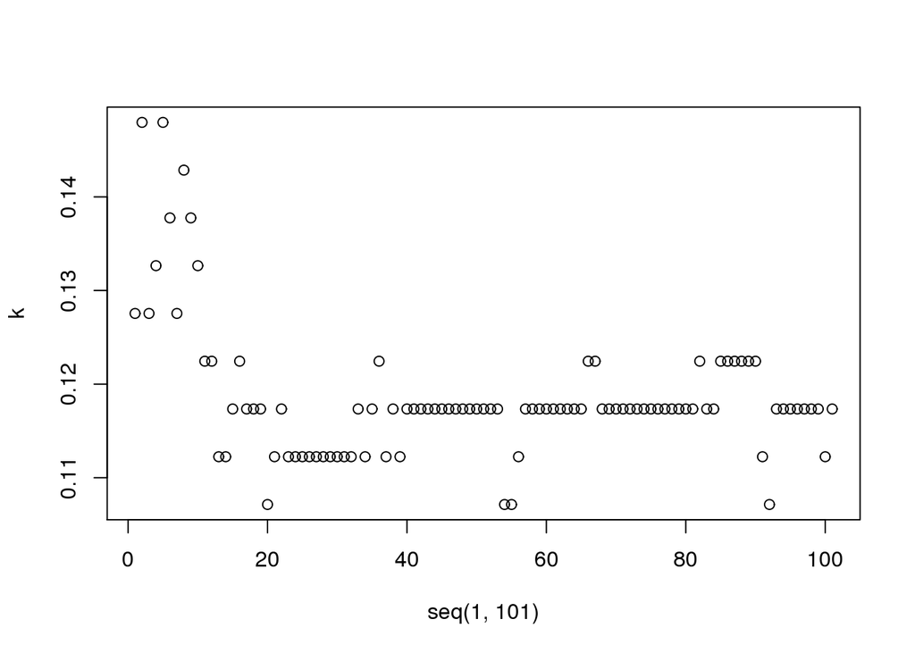

```r
k<-seq(1,100)
for (i in 1:101) {
  pred.knn <- class:::knn(train_matrix_knn, test_matrix_knn, cl=mpg_cl_knn,  k = i)
  k[i]<-mean(pred.knn != mpg_matrix_knn_test)
}

plot(k~seq(1,101))
```

# 4.7.13 Use Boston data set, fit classification models in order to predict whether a given suburb has a crime rate above or below the median. Explore logistic regression, LDA, KNN using various subsets of predictors. Describe findings.

```r
Boston$above_median<-ifelse(Boston$crim>0.25651,1,0)

## 50% = training, 50% = test
size <- floor(0.5 * nrow(Boston))
set.seed(123)
training_rows<- sample(seq_len(nrow(Boston)), size = size)

train_data <- Boston[training_rows, ] #196 rows
test_data <- Boston[-training_rows, ]
```

Logistic regression

```r
glm_model <- glm(above_median ~ . - above_median - crim, data = train_data, family = binomial)

probs <- predict(glm_model, test_data, type = "response")
pred_glm <- rep(0, length(probs))
pred_glm[probs > 0.5] <- 1
table(pred_glm, test_data$above_median)
```

```
##
## pred_glm   0   1
##        0 108  16
##        1  17 112
```

```r
mean(pred_glm != test_data$above_median)
```

```
## [1] 0.1304348
```

using all data and logistic, my error rate is 0.1304348

LDA

```r
lda_model <- lda(above_median ~. -crim -above_median, data = train_data)
pred_lda <- predict(lda_model, newdata=test_data)
table(pred_lda$class, test_data$above_median)
```

```
##
##       0   1
##   0 117  33
##   1   8  95
```

```r
mean(pred_lda$class != test_data$above_median)
```

```
## [1] 0.1620553
```

using all data and LDA, my error rate is .1620553

QDA

```r
qda_model <- qda(above_median ~. - above_median - crim   , data = train_data)
pred_qda <- predict(qda_model, newdata=test_data)
table(pred_qda$class, test_data$above_median)
```

```
##
##       0   1
##   0 118  28
##   1   7 100
```

```r
mean(pred_qda$class != test_data$above_median)
```

```
## [1] 0.1383399
```

KNN

```r
knn_matrix <- data.matrix(train_data)
knn_matrix2 <- data.matrix(test_data)

knn_train_matrix <- knn_matrix[,-c(1,15,16)]
knn_test_matrix <- knn_matrix2[,-c(1,15,16)]
train_above_median<-data.matrix(test_data$above_median)
knn_crim_test<-knn_matrix2[,15]
set.seed(1)
pred_knn <- class:::knn(knn_train_matrix,knn_test_matrix, cl=train_above_median,  k = 1)

table(pred_knn, knn_crim_test)
```

```
##         knn_crim_test
## pred_knn  0  1
##        0 77 64
##        1 48 64
```

```r
mean(pred_knn != knn_crim_test)
```

```
## [1] 0.4426877
```

For k=1, I get a test error rate of .443

comparing K’s

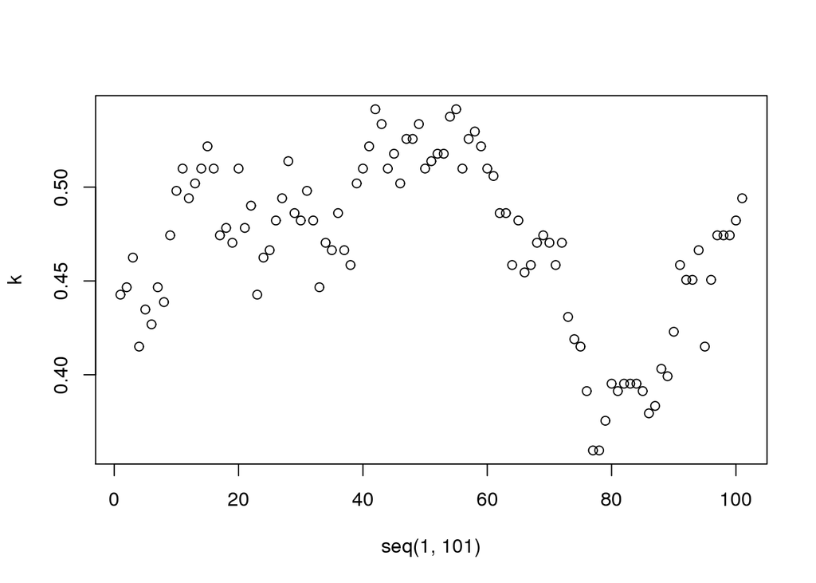

```r
k<-seq(1,100)
for (i in 1:101) {
  pred_knn <- class:::knn(knn_train_matrix,knn_test_matrix, cl=train_above_median,  k = i)
  k[i]<-mean(pred_knn != knn_crim_test)
}

plot(k~seq(1,101))
```

According to this, it seems like the best model uses a very high k value of around 80, but even then, knn clearly isn’t doing a great job here because the test rate is well over .3 at all k’s